# Analysis document

# 1 Data Source

This document uses UC Irvine’s Machine Learning Repository: Heart Disease Data Set. This directory contains 4 databases concerning heart disease diagnosis. The data was collected from four different locations:

Cleveland Clinic Foundation (cleveland.data) Hungarian Institute of Cardiology, Budapest (hungarian.data) V.A. Medical Center, Long Beach, CA (long-beach-va.data) University Hospital, Zurich, Switzerland (switzerland.data)

For our purposes, we would take the Cleveland Clinic Foundation data. Cleveland Clinic Heart Disease dataset which contains 13 variables related to patient diagnostics and one outcome variable indicating the presence or absence of heart disease. The data was accessed from the UCI Machine Learning Repository. The goal is to be able to accurately classify patients whether they have heart disease or not based on diagnostic test data.

# 2 Question Asked

Which health biomarkers are considered to be the most important when trying to predict the presence of heart disease?

# 3 Load Libraries

```r
# Load in Packages
library("readr")
library("readxl")
library("dplyr")
library("tidyr")
library("ggplot2")
library("VIM")
library("class")
library("tidyverse")

# For analysis
library("keras")
library("RColorBrewer")
library("broom")
library("glmnet")
library("caret")
library("pROC")
library("MLeval")
library("vip")
library("rpart")
library("rpart.plot")
library("rattle")
library("viridis")
library("mltools")
library("randomForest")
library("psych") #matrix plots
library("corrplot") # used for correlation plot
library("ggpubr") #used for qqplots
library("gridExtra") #arranging qqplots in 1 graph
library("rpart")
library("rpart.plot")
library("gbm")
library("randomForest")
library("neuralnet")
library("e1071")
library("glmnet")
library("pROC")
library("PRROC")
library("RWeka")
library("performanceEstimation")
library("NeuralNetTools")
```

# 4 Wrangling Data

```r
analysis_data <- read.table(url("https://archive.ics.uci.edu/ml/machine-learning-databases/heart-disease/processed.cleveland.data"),
                          sep = ",",
                          header = FALSE)
# Retrieve column names from: "https://archive.ics.uci.edu/ml/datasets/heart+disease"
colnames(analysis_data) <- c("Age",
                             "Sex",
                             "Chest_pain_type",
                             "Resting_bp",
                             "Cholesterol",
                             "Fasting_blood_sugar",
                             "Resting_ecg",
                             "Max_heart_rate",
                             "Exercise_induced_angina",
                             "ST_depression_by_exercise",
                             "Slope_peak_exercise_ST",
                             "Num_major_vessels_flouro",
                             "Thalassemia",
                             "Diagnosis_Heart_Disease")

# Check the dataset
glimpse(analysis_data) # Get str for all columns in neat fashion
```

```
## Rows: 303
## Columns: 14
## $ Age                       <dbl> 63, 67, 67, 37, 41, 56, 62, 57, 63, 53, 57, ~
## $ Sex                       <dbl> 1, 1, 1, 1, 0, 1, 0, 0, 1, 1, 1, 0, 1, 1, 1,~
## $ Chest_pain_type           <dbl> 1, 4, 4, 3, 2, 2, 4, 4, 4, 4, 4, 2, 3, 2, 3,~
## $ Resting_bp                <dbl> 145, 160, 120, 130, 130, 120, 140, 120, 130,~
## $ Cholesterol               <dbl> 233, 286, 229, 250, 204, 236, 268, 354, 254,~
## $ Fasting_blood_sugar       <dbl> 1, 0, 0, 0, 0, 0, 0, 0, 0, 1, 0, 0, 1, 0, 1,~
## $ Resting_ecg               <dbl> 2, 2, 2, 0, 2, 0, 2, 0, 2, 2, 0, 2, 2, 0, 0,~
## $ Max_heart_rate            <dbl> 150, 108, 129, 187, 172, 178, 160, 163, 147,~
## $ Exercise_induced_angina   <dbl> 0, 1, 1, 0, 0, 0, 0, 1, 0, 1, 0, 0, 1, 0, 0,~
## $ ST_depression_by_exercise <dbl> 2.3, 1.5, 2.6, 3.5, 1.4, 0.8, 3.6, 0.6, 1.4,~
## $ Slope_peak_exercise_ST    <dbl> 3, 2, 2, 3, 1, 1, 3, 1, 2, 3, 2, 2, 2, 1, 1,~
## $ Num_major_vessels_flouro  <chr> "0.0", "3.0", "2.0", "0.0", "0.0", "0.0", "2~
## $ Thalassemia               <chr> "6.0", "3.0", "7.0", "3.0", "3.0", "3.0", "3~
## $ Diagnosis_Heart_Disease   <int> 0, 2, 1, 0, 0, 0, 3, 0, 2, 1, 0, 0, 2, 0, 0,~
```

```r
dim(analysis_data) # Dimension of the dataset
```

```
## [1] 303  14
```

```r
## As we see that some qualitative variables in the data frame are included as quantitative variables.
# Correcting column types
cols <- c("Sex", "Chest_pain_type", "Fasting_blood_sugar", "Resting_ecg", "Exercise_induced_angina",
          "Slope_peak_exercise_ST")
analysis_data <- analysis_data %>% mutate_at(cols, list(as.factor))

# Cheking the dataset again
glimpse(analysis_data)
```

```
## Rows: 303
## Columns: 14
## $ Age                       <dbl> 63, 67, 67, 37, 41, 56, 62, 57, 63, 53, 57, ~
## $ Sex                       <fct> 1, 1, 1, 1, 0, 1, 0, 0, 1, 1, 1, 0, 1, 1, 1,~
## $ Chest_pain_type           <fct> 1, 4, 4, 3, 2, 2, 4, 4, 4, 4, 4, 2, 3, 2, 3,~
## $ Resting_bp                <dbl> 145, 160, 120, 130, 130, 120, 140, 120, 130,~
## $ Cholesterol               <dbl> 233, 286, 229, 250, 204, 236, 268, 354, 254,~
## $ Fasting_blood_sugar       <fct> 1, 0, 0, 0, 0, 0, 0, 0, 0, 1, 0, 0, 1, 0, 1,~
## $ Resting_ecg               <fct> 2, 2, 2, 0, 2, 0, 2, 0, 2, 2, 0, 2, 2, 0, 0,~
## $ Max_heart_rate            <dbl> 150, 108, 129, 187, 172, 178, 160, 163, 147,~
## $ Exercise_induced_angina   <fct> 0, 1, 1, 0, 0, 0, 0, 1, 0, 1, 0, 0, 1, 0, 0,~
## $ ST_depression_by_exercise <dbl> 2.3, 1.5, 2.6, 3.5, 1.4, 0.8, 3.6, 0.6, 1.4,~
## $ Slope_peak_exercise_ST    <fct> 3, 2, 2, 3, 1, 1, 3, 1, 2, 3, 2, 2, 2, 1, 1,~
## $ Num_major_vessels_flouro  <chr> "0.0", "3.0", "2.0", "0.0", "0.0", "0.0", "2~
## $ Thalassemia               <chr> "6.0", "3.0", "7.0", "3.0", "3.0", "3.0", "3~
## $ Diagnosis_Heart_Disease   <int> 0, 2, 1, 0, 0, 0, 3, 0, 2, 1, 0, 0, 2, 0, 0,~
```

The main idea/goal here is to use the 13 variables to predict the Diagnosis_Heart_Disease variable, or in other words to predict the heart disease event.

## 4.1 Inspecting NA’s if there

```r
## Casual inspection suggests some NA's being present in the form of "?". We change them to NA
analysis_data[analysis_data == "?"] <- NA

# Now we can quantify the missing values
sum(is.na(analysis_data))
```

```
## [1] 6
```

```r
analysis_data %>%
  purrr::map_df(~ sum(is.na(.)))
```

```
## # A tibble: 1 x 14
##     Age   Sex Chest_pain_type Resting_bp Cholesterol Fasting_blood_sugar
##   <int> <int>           <int>      <int>       <int>               <int>
## 1     0     0               0          0           0                   0
## # ... with 8 more variables: Resting_ecg <int>, Max_heart_rate <int>,
## #   Exercise_induced_angina <int>, ST_depression_by_exercise <int>,
## #   Slope_peak_exercise_ST <int>, Num_major_vessels_flouro <int>,
## #   Thalassemia <int>, Diagnosis_Heart_Disease <int>
```

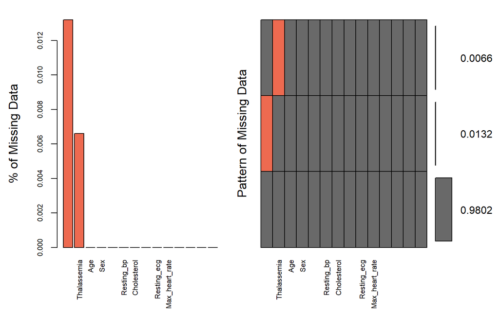

```
##
##  Variables sorted by number of missings:
##                   Variable      Count
##   Num_major_vessels_flouro 0.01320132
##                Thalassemia 0.00660066
##                        Age 0.00000000
##                        Sex 0.00000000
##            Chest_pain_type 0.00000000
##                 Resting_bp 0.00000000
##                Cholesterol 0.00000000
##        Fasting_blood_sugar 0.00000000
##                Resting_ecg 0.00000000
##             Max_heart_rate 0.00000000
##    Exercise_induced_angina 0.00000000
##  ST_depression_by_exercise 0.00000000
##     Slope_peak_exercise_ST 0.00000000
##    Diagnosis_Heart_Disease 0.00000000
```

```r
# Visualizing NA Values
aggr(analysis_data, col=c("dimgrey", "coral2"), numbers=TRUE,
                   sortVars=TRUE, labels=names(analysis_data), cex.axis=0.7,
                   gap=3, ylab=c("% of Missing Data", "Pattern of Missing Data"))
```

So we just drop rows containing NA

```r
analysis_data <- analysis_data %>% drop_na()

paste("Number of rows left after dropping rows with NA: ", nrow(analysis_data))
```

```
## [1] "Number of rows left after dropping rows with NA:  297"
```

Now its important to know whether the dataset is balanced across the levels of dependent variable

```r
analysis_data %>%
  drop_na() %>%
  group_by(Diagnosis_Heart_Disease) %>%
  count() %>%
  ungroup()
```

```
## # A tibble: 5 x 2
##   Diagnosis_Heart_Disease     n
##                     <int> <int>
## 1                       0   160
## 2                       1    54
## 3                       2    35
## 4                       3    35
## 5                       4    13
```

Now we see that outcome/Dependent variable has 5 levels. However, the UCI documentation suggests that any value above 0 in ‘Diagnosis_Heart_Disease’ indicates the presence of heart disease. As the primary motivation of our study here is to be able to predict the Heart_Disease_Status alone and not the grades within the heart disease, we can clump all levels above 0, so that we can have a binary variable woith levels 0 and 1, indicating - Heart disease absent or present.

```r
analysis_data$Thalassemia <- as.factor(analysis_data$Thalassemia)
# Recoding Diagnosis_Heart_Disease column binary, 0 = no heart disease, 1 = heart disease present
# Also other qualitative variables' levels needs to be meaningful
analysis_data <- analysis_data %>%
  mutate(Diagnosis_Heart_Disease = ifelse(Diagnosis_Heart_Disease >0,1, Diagnosis_Heart_Disease)) %>%
  mutate_at("Diagnosis_Heart_Disease", as.factor) %>%
  mutate(Num_major_vessels_flouro = as.numeric(as.factor(Num_major_vessels_flouro))) %>%
  mutate(Sex = recode_factor(Sex, `0` = "female",
                                  `1` = "male" ),
         Chest_pain_type = recode_factor(Chest_pain_type, `1` = "typical",
                                                          `2` = "atypical",
                                                          `3` = "non_angina",
                                                          `4` = "asymptomatic"),
         Fasting_blood_sugar = recode_factor(Fasting_blood_sugar, `0` = "_Less_120mg_dl",
                                                                  `1` = "_More_120mg_dl"),
         Resting_ecg = recode_factor(Resting_ecg, `0` = "normal",
                                                  `1` = "ST_T_abnormality",
                                                  `2` = "LV_hypertrophy"),
         Exercise_induced_angina = recode_factor(Exercise_induced_angina, `0` = "no",
                                                                          `1` = "yes"),
         Slope_peak_exercise_ST  = recode_factor(Slope_peak_exercise_ST, `1` = "up_sloping",
                                                                            `2` = "flat",
                                                                            `3` = "down_sloping"),
         Thalassemia = recode_factor(Thalassemia, `3.0` = "normal",
                                                  `6.0` = "fixed_defect",
                                                  `7.0` = "reversible_defect"),
         Diagnosis_Heart_Disease = recode_factor(Diagnosis_Heart_Disease, `0` = "No_HD",
                                                                          `1` = "HD"))
```

# 5 Exploratory Analysis

## 5.1 Distribution of quantitative variables

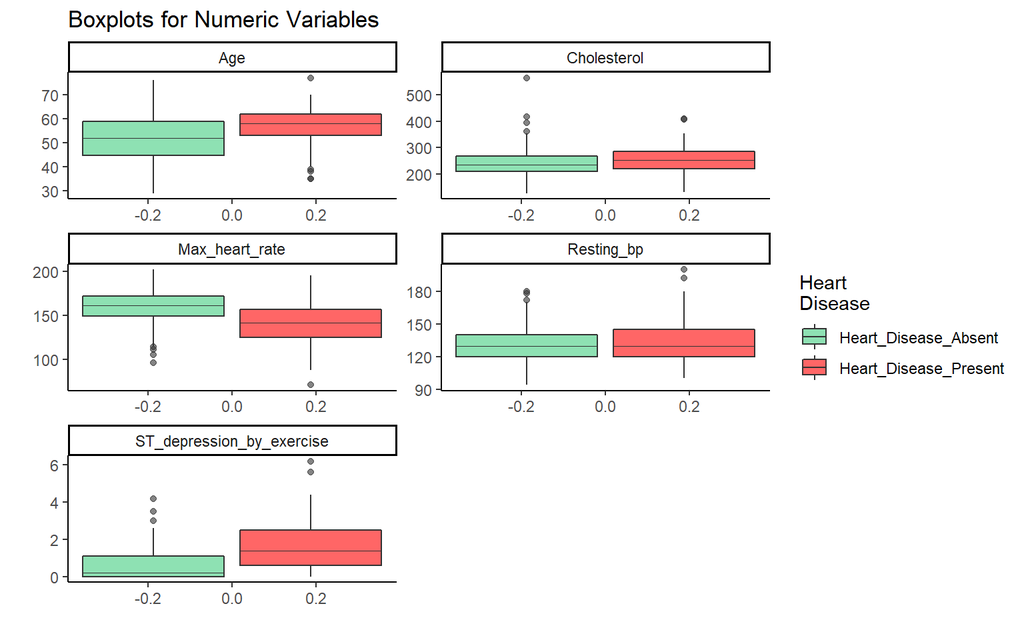

```r
# Boxplots for quantitative variables, split by Disease status

# Gather the variables to plot by key
df1 <- analysis_data  %>% dplyr::select(Age,
                                 Resting_bp,
                                 Cholesterol,
                                 Max_heart_rate,
                                 ST_depression_by_exercise,
                                 Diagnosis_Heart_Disease) %>%
                          gather(key = "key",
                                 value = "value",
                                 -Diagnosis_Heart_Disease)

# Visualize numeric variables as boxplots
df1 %>% ggplot(aes(y = value)) +
               geom_boxplot(aes(fill = Diagnosis_Heart_Disease),
                            alpha  = .6,
                            fatten = .7) +
                ggtitle("Boxplots for Numeric Variables") +
                xlab("") +
                ylab("") +
                scale_fill_manual(values = c("seagreen3", "red"),
                                  name   = "Heart\nDisease",
                                  labels = c("Heart_Disease_Absent", "Heart_Disease_Present")) +
                theme(axis.text.x  = element_blank(), axis.ticks.x = element_blank()) +
                theme_classic() +
                facet_wrap(~ key, scales = "free", ncol   = 2)
```

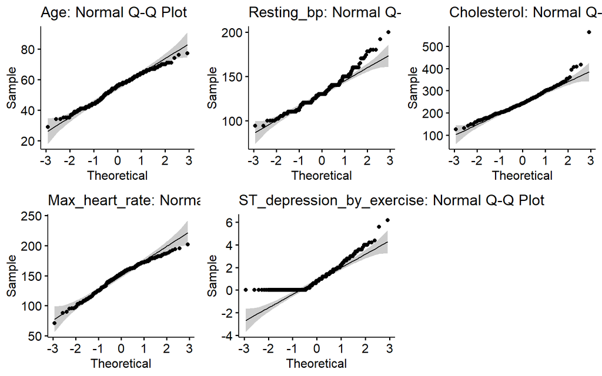

```r
# Checking for normality of continuous variables
q1 <- ggqqplot(analysis_data$Age, main="Age: Normal Q-Q Plot")
q2 <- ggqqplot(analysis_data$Resting_bp, main="Resting_bp: Normal Q-Q Plot")
q3 <- ggqqplot(analysis_data$Cholesterol, main="Cholesterol: Normal Q-Q Plot")
q4 <- ggqqplot(analysis_data$Max_heart_rate, main="Max_heart_rate: Normal Q-Q Plot")
q5 <- ggqqplot(analysis_data$ST_depression_by_exercise, main="ST_depression_by_exercise: Normal Q-Q Plot")

grid.arrange(q1, q2, q3, q4, q5, ncol=3)
```

Since some variables like Max_heart_rate and cholesterol are numeric types, and the values range for quite a bit(cholesterol has a min of 126 and a max of 564), its best we normalise them before proceeding with any analysis.

```r
# Normalizing data
scaling <- scale((analysis_data) %>%
                                dplyr::select(c("Resting_bp", "Cholesterol", "Max_heart_rate", "ST_depression_by_exercise", "Age", "Num_major_vessels_flouro")))
scaling <- data.frame(scaling)
analysis_data$Resting_bp <- scaling$Resting_bp
analysis_data$Cholesterol <- scaling$Cholesterol
analysis_data$Max_heart_rate <- scaling$Max_heart_rate
analysis_data$ST_depression_by_exercise <- scaling$ST_depression_by_exercise
analysis_data$Age <- scaling$Age
analysis_data$Num_major_vessels_flouro <- scaling$Num_major_vessels_flouro

glimpse(analysis_data)
```

```
## Rows: 297
## Columns: 14
## $ Age                       <dbl> 0.93460326, 1.37660512, 1.37660512, -1.93840~
## $ Sex                       <fct> male, male, male, male, female, male, female~
## $ Chest_pain_type           <fct> typical, asymptomatic, asymptomatic, non_ang~
## $ Resting_bp                <dbl> 0.74911571, 1.59357687, -0.65831955, -0.0953~
## $ Cholesterol               <dbl> -0.27597761, 0.74330055, -0.35290426, 0.0509~
## $ Fasting_blood_sugar       <fct> _More_120mg_dl, _Less_120mg_dl, _Less_120mg_~
## $ Resting_ecg               <fct> LV_hypertrophy, LV_hypertrophy, LV_hypertrop~
## $ Max_heart_rate            <dbl> 0.01746496, -1.81327350, -0.89790427, 1.6302~
## $ Exercise_induced_angina   <fct> no, yes, yes, no, no, no, no, yes, no, yes, ~
## $ ST_depression_by_exercise <dbl> 1.06716416, 0.38113006, 1.32442695, 2.096215~
## $ Slope_peak_exercise_ST    <fct> down_sloping, flat, flat, down_sloping, up_s~
## $ Num_major_vessels_flouro  <dbl> -0.7207596, 2.4742493, 1.4092463, -0.7207596~
## $ Thalassemia               <fct> fixed_defect, normal, reversible_defect, nor~
## $ Diagnosis_Heart_Disease   <fct> No_HD, HD, HD, No_HD, No_HD, No_HD, HD, No_H~
```

The boxplots suggests that these conditions are associated in various degrees (some very slightly, some in a major way as seen by the median lines not aligning between the Disease status) with an increased prevalence of heart disease: Higher age Lower max heart rate achieved Higher cholesterol Higher ST depression induced by exercise relative to rest

## 5.2 Lets see how the categorical variables are distributed wrt disease status

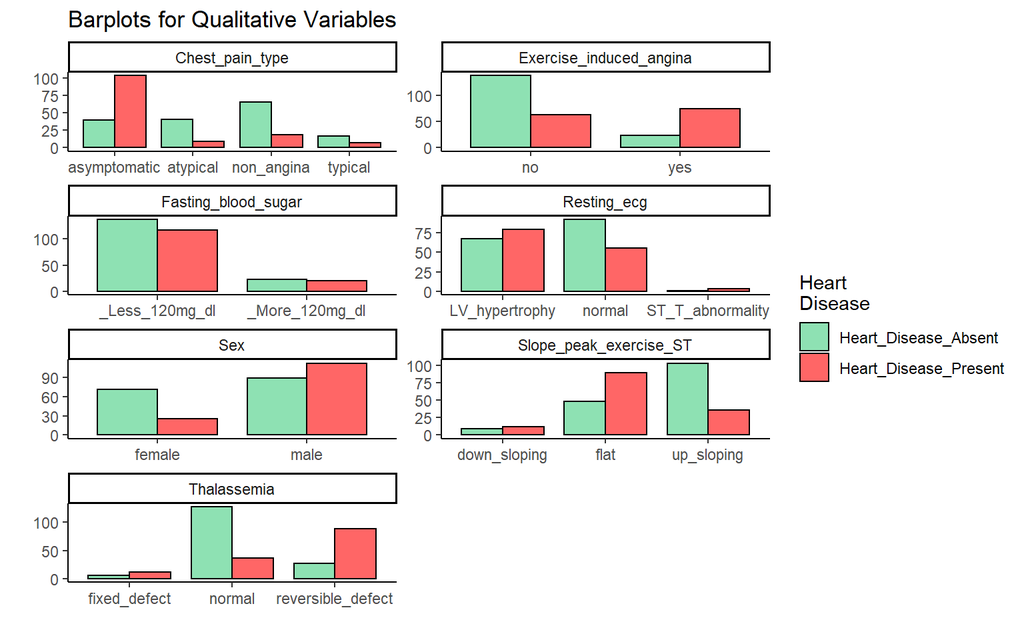

```r
# Barplots for qualitative variables, split by Disease status

# Gather the variables to plot by key
df2 <- analysis_data  %>% dplyr::select(Sex,
                                 Chest_pain_type,
                                 Fasting_blood_sugar,
                                 Resting_ecg,
                                 Exercise_induced_angina,
                                 Slope_peak_exercise_ST,
                                 Thalassemia,
                                 Diagnosis_Heart_Disease) %>%
                          gather(key = "key",
                                 value = "value",
                                 -Diagnosis_Heart_Disease)
#Visualize numeric variables as boxplots
df2 %>% ggplot(aes(value)) +
               geom_bar(aes(x = value,
                            fill     = Diagnosis_Heart_Disease),
                            alpha    = .6,
                            position = "dodge",
                            color    = "black",
                            width    = .8) +
                ggtitle("Barplots for Qualitative Variables") +
                xlab("") +
                ylab("") +
                scale_fill_manual(values = c("seagreen3", "red"),
                                  name   = "Heart\nDisease",
                                  labels = c("Heart_Disease_Absent", "Heart_Disease_Present")) +
                theme(axis.text.y  = element_blank(), axis.ticks.y = element_blank()) +
                theme_classic() +
                facet_wrap(~ key, scales = "free", nrow   = 4)
```

The barplots suggests that these conditions are associated in various degrees (judging by the spread of the distributuion of categorical variables across disease status) with an increased prevalence of heart disease: Higher grade angina chest pain (grade 4) Presence of exercise induced angina Male Higher thalassemia score Higher Resting ECG score (grade 2) We see that >50% males have heart disease whereas, ~25% females, have the heart disease. Could this mean that the data is sex-biased? Also, in general, sex, age, cholesteril, angina status are known variables to be associated with Heart Disease and wrt data we have here we see similar trend.

Correlated variables in any model causes incorrect/inflated inferences and hence such multicollinearity should be checked before implmenting any analysis methods.

## 5.3 We check the correlations between all the numerical attributes

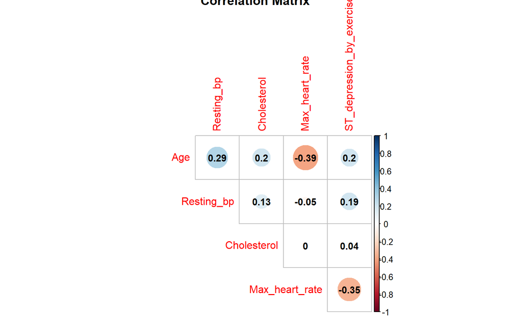

```r
cols <- c('Sex', 'Chest_pain_type', 'Fasting_blood_sugar', 'Resting_ecg', 'Exercise_induced_angina', 'Slope_peak_exercise_ST', 'Num_major_vessels_flouro', 'Thalassemia', 'Diagnosis_Heart_Disease')
corrplot::corrplot(cor(analysis_data[, -match(cols, colnames(analysis_data))]), # subset the data for only numeric columns
         method="circle",
         type = "upper",
         number.cex = .9,
         insig = 'blank',
         diag=FALSE,
         addCoef.col ='black',
         title = "Correlation Matrix")
```

## 5.4 Prepare for Model Building

```r
# Splitting the data into training and test set using caret package
set.seed(123)
training_samples <- analysis_data$Diagnosis_Heart_Disease %>%
                        createDataPartition(p = 0.7, list = FALSE)
train_data  <- analysis_data[training_samples, ]
test_data <- analysis_data[-training_samples, ]

# Now using the model.matrix() to create matrix of predictors which then automatically converts categorical predictors to appropriate dummy variables for glmnet()
# Dummy code categorical predictor variables
x <- model.matrix(Diagnosis_Heart_Disease ~ ., data = train_data[, -c(2:3)])[,-1]

paste("No. of rows in the Training data: ", nrow(train_data))
```

```
## [1] "No. of rows in the Training data:  208"
```

```r
paste("No. of rows in the Test data: ", nrow(test_data))
```

```
## [1] "No. of rows in the Test data:  89"
```

```r
paste("Test to Train data ratio is: ", nrow(test_data)/(nrow(train_data) + nrow(test_data)))
```

```
## [1] "Test to Train data ratio is:  0.2996632996633"
```

# 6 Models

## 6.1 Logistic Regression (GLM)

```r
set.seed(223)
# Fit the logistic regression model with glm function: generalized linear model using binomial for logistic regression
glm_fit <- train(Diagnosis_Heart_Disease ~ .,
                 data = train_data,
                 method = "glm",
                 family = "binomial")
# Test the model using the predict function
glm_pred <- predict(glm_fit, newdata = test_data)

# Confusion matrix
glm_conf_matrix <- confusionMatrix(table(test_data$Diagnosis_Heart_Disease,
                                         glm_pred))

# Extract parameters from the confusion matrix
accuracy_glm <- glm_conf_matrix$overall["Accuracy"]
sensitivity_glm <- glm_conf_matrix$byClass["Sensitivity"]
specificity_glm <- glm_conf_matrix$byClass["Specificity"]
f1_glm <- 2*sensitivity_glm*specificity_glm/(sensitivity_glm+specificity_glm)

# AUC
glm_AUC <- roc(test_data$Diagnosis_Heart_Disease, as.numeric(glm_pred))["auc"]
glm_AUC <- as.numeric(substr(glm_AUC, -7, 5))

# GLM output for viewing later
model_accs <- tibble(Method = "Generalized Linear Model",
                     Accuracy = accuracy_glm,
                     "Sensitivity/Recall" = sensitivity_glm,
                     "F1 score" = f1_glm,
                     AUC = glm_AUC)
model_accs %>% knitr::kable()
```

| Method | Accuracy | Sensitivity/Recall | F1 score | AUC |
| --- | --- | --- | --- | --- |
| Generalized Linear Model | 0.8651685 | 0.8333333 | 0.8719346 | 0.858 |

Interestingly, we get a warning message when running glm() above : “prediction from a rank-deficient fit may be misleading”. Now this could be due to several reasons, either there are multicollinear variables present OR several variables exist with NA’s in them OR adding more variables than the number of samples etc. Could we do something about it by specifying a Bayesian version of GLM, invoking a flat but not completely noninformative prior?

## 6.2 Bayesian GLM

```r
set.seed(123)
# Fit the logistic regression model with bayesglm function: generalized linear model using binomial for logistic regression
bayesglm_fit <- train(Diagnosis_Heart_Disease ~ .,
                 data = train_data,
                 method = "bayesglm",
                 family = "binomial")

# Test the model using the predict function
bayesglm_pred <- predict(bayesglm_fit, newdata = test_data)

# Confusion matrix
bayesglm_conf_matrix <- confusionMatrix(table(test_data$Diagnosis_Heart_Disease,
                                         bayesglm_pred))

# Extract parameters from the confusion matrix
accuracy_bayesglm <- bayesglm_conf_matrix$overall["Accuracy"]
sensitivity_bayesglm <- bayesglm_conf_matrix$byClass["Sensitivity"]
specificity_bayesglm <- bayesglm_conf_matrix$byClass["Specificity"]
f1_bayesglm <- 2*sensitivity_bayesglm*specificity_bayesglm/(sensitivity_bayesglm+specificity_bayesglm)

# AUC
bayesglm_AUC <- roc(test_data$Diagnosis_Heart_Disease, as.numeric(bayesglm_pred))["auc"]
bayesglm_AUC <- as.numeric(substr(bayesglm_AUC, -7, 5))

# bayesglm output for viewing later
model_accs <- bind_rows(model_accs,
                        tibble(Method = "Bayesian GLM",
                               Accuracy = accuracy_bayesglm,
                               "Sensitivity/Recall" = sensitivity_bayesglm,
                               "F1 score" = f1_bayesglm,
                               AUC = bayesglm_AUC))
model_accs %>% knitr::kable()
```

| Method | Accuracy | Sensitivity/Recall | F1 score | AUC |
| --- | --- | --- | --- | --- |
| Generalized Linear Model | 0.8651685 | 0.8333333 | 0.8719346 | 0.858 |
| Bayesian GLM | 0.8876404 | 0.8518519 | 0.8950472 | 0.881 |

We see that with this the warning of rank deficient matrix is avoided.

## 6.3 Regression Tree

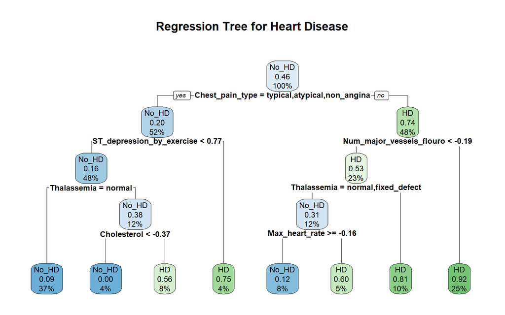

```r
set.seed(123)
# Fit the regression tree model with rpart function
rt_fit <- rpart(Diagnosis_Heart_Disease ~ .,
                 data = train_data,
                 method = "class")

# Plot the regression tree
rpart.plot(rt_fit,
           cex=0.75,
           main = "Regression Tree for Heart Disease")
```

```r
# Test the model using the predict function
rt_pred <- predict(rt_fit, test_data, type = "class")

# Confusion matrix
rt_cMatrix <- confusionMatrix(table(test_data$Diagnosis_Heart_Disease, rt_pred))

# Extract parameters from the confusion matrix
accuracy_rt <- rt_cMatrix$overall["Accuracy"]
sensitivity_rt <- rt_cMatrix$byClass["Sensitivity"]
specificity_rt <- rt_cMatrix$byClass["Specificity"]
f1_rt <- 2*sensitivity_rt*specificity_rt/(sensitivity_rt+specificity_rt)

# AUC
rt_AUC <- roc(test_data$Diagnosis_Heart_Disease,as.numeric(rt_pred))["auc"]
rt_AUC <- as.numeric(substr(rt_AUC, -7, 5))

# RT output for viewing later
model_accs <- bind_rows(model_accs,
                        tibble(Method = "Regression Tree Model",
                               Accuracy = accuracy_rt,
                               "Sensitivity/Recall" = sensitivity_rt,
                               "F1 score" = f1_rt,
                               AUC = rt_AUC)
)
model_accs %>% knitr::kable()
```

| Method | Accuracy | Sensitivity/Recall | F1 score | AUC |
| --- | --- | --- | --- | --- |
| Generalized Linear Model | 0.8651685 | 0.8333333 | 0.8719346 | 0.858 |
| Bayesian GLM | 0.8876404 | 0.8518519 | 0.8950472 | 0.881 |
| Regression Tree Model | 0.7865169 | 0.8717949 | 0.7886598 | 0.793 |

The regression tree is interesting since Chest_pain_type is shown to be the most important classifier for the patient samples.

## 6.4 Random Forest (RF)

```r
set.seed(123)
# Fit the Random Forest model with rpart function
rf_fit <- randomForest(Diagnosis_Heart_Disease ~ .,
                 data = train_data,
                 importance=TRUE,
                 ntree=500)

# Test the model using the predict function
rf_pred <- predict(rf_fit, test_data)

# Confusion matrix
rf_cMatrix <- confusionMatrix(table(test_data$Diagnosis_Heart_Disease, rf_pred))

# Extract parameters from the confusion matrix
accuracy_rf <- rf_cMatrix$overall["Accuracy"]
sensitivity_rf <- rf_cMatrix$byClass["Sensitivity"]
specificity_rf <- rf_cMatrix$byClass["Specificity"]
f1_rf <- 2*sensitivity_rf*specificity_rf/(sensitivity_rf + specificity_rf)

# AUC
rf_AUC <- roc(test_data$Diagnosis_Heart_Disease, as.numeric(rf_pred))["auc"]
rf_AUC <- as.numeric(substr(rf_AUC, -7, 5))

# RF output for viewing later
model_accs <- bind_rows(model_accs,
                        tibble(Method = "Random Forest Model",
                               Accuracy = accuracy_rf,
                               "Sensitivity/Recall" = sensitivity_rf,
                               "F1 score" = f1_rf,
                               AUC = rf_AUC)
)
model_accs %>% knitr::kable()
```

| Method | Accuracy | Sensitivity/Recall | F1 score | AUC |
| --- | --- | --- | --- | --- |
| Generalized Linear Model | 0.8651685 | 0.8333333 | 0.8719346 | 0.858 |
| Bayesian GLM | 0.8876404 | 0.8518519 | 0.8950472 | 0.881 |
| Regression Tree Model | 0.7865169 | 0.8717949 | 0.7886598 | 0.793 |
| Random Forest Model | 0.8651685 | 0.8333333 | 0.8719346 | 0.858 |

## 6.5 SVM

```r
set.seed(123)
# Fit the SVM model with the svm function
svm_fit <- svm(Diagnosis_Heart_Disease ~ .,
                 data = train_data)

# Test the model using the predict function
svm_pred <- predict(svm_fit, test_data)

# Confusion matrix
svm_cMatrix <- confusionMatrix(table(test_data$Diagnosis_Heart_Disease, svm_pred))

# Extract parameters from the confusion matrix
accuracy_svm <- svm_cMatrix$overall["Accuracy"]
sensitivity_svm <- svm_cMatrix$byClass["Sensitivity"]
specificity_svm <- svm_cMatrix$byClass["Specificity"]
f1_svm <- 2*sensitivity_svm*specificity_svm/(sensitivity_svm+specificity_svm)

# AUC
svm_AUC <- roc(test_data$Diagnosis_Heart_Disease,
               as.numeric(svm_pred))["auc"]
svm_AUC <- as.numeric(substr(svm_AUC, -7, 5))

# SVM output for viewing later
model_accs <- bind_rows(model_accs,
                        tibble(Method = "Support-Vector Machine",
                               Accuracy = accuracy_svm,
                               "Sensitivity/Recall" = sensitivity_svm,
                               "F1 score" = f1_svm,
                               AUC = svm_AUC)
)
model_accs %>% knitr::kable()
```

| Method | Accuracy | Sensitivity/Recall | F1 score | AUC |
| --- | --- | --- | --- | --- |
| Generalized Linear Model | 0.8651685 | 0.8333333 | 0.8719346 | 0.858 |
| Bayesian GLM | 0.8876404 | 0.8518519 | 0.8950472 | 0.881 |
| Regression Tree Model | 0.7865169 | 0.8717949 | 0.7886598 | 0.793 |
| Random Forest Model | 0.8651685 | 0.8333333 | 0.8719346 | 0.858 |
| Support-Vector Machine | 0.8764045 | 0.8490566 | 0.8815672 | 0.871 |

## 6.6 Neural Networks

```r
set.seed(123)
# Since neuralnet only deals with quantitative variables, we convert all the qualitative variables (factors) to binary ("dummy") variables, with the model.matrix function
model_train <- as.data.frame(model.matrix( ~ Age + Sex + Chest_pain_type + Resting_bp + Cholesterol + Fasting_blood_sugar + Resting_ecg + Max_heart_rate +
                     Exercise_induced_angina + ST_depression_by_exercise + Slope_peak_exercise_ST + Num_major_vessels_flouro + Thalassemia + Diagnosis_Heart_Disease,
                    data = train_data))

names(model_train) <- make.unique(names(model_train))
# Fit the neural networks model with the neuralnet function
nn_fit <- neuralnet::neuralnet(Diagnosis_Heart_DiseaseHD ~ Age + Sexmale + Chest_pain_typeatypical +
                                                            Chest_pain_typenon_angina + Chest_pain_typeasymptomatic + Resting_bp +
                                                            Cholesterol + Fasting_blood_sugar_More_120mg_dl +  Resting_ecgST_T_abnormality +
                                                            Resting_ecgLV_hypertrophy + Max_heart_rate + Exercise_induced_anginayes +
                                                            ST_depression_by_exercise + Slope_peak_exercise_STflat + Slope_peak_exercise_STdown_sloping +
                                                            Num_major_vessels_flouro + Thalassemiafixed_defect + Thalassemiareversible_defect ,
                    data = model_train ,
                    hidden = 10,
                    act.fct = "logistic",
                    threshold = 0.05,
                    linear.output = FALSE,
                    lifesign = "minimal") # thresh varying from 0.01, to 0.05
```

```
## hidden: 10    thresh: 0.05    rep: 1/1    steps:     106 error: 1.51896  time: 0.03 secs
```

```r
# Plot the fit
plot(nn_fit)

# Test the model using the predict function
# Since neuralnet only deals with quantitative variables, we convert all the qualitative variables (factors) to binary ("dummy") variables, with the model.matrix function
model_test <- model.matrix( ~ Age + Sex + Chest_pain_type + Resting_bp + Cholesterol + Fasting_blood_sugar + Resting_ecg + Max_heart_rate +
                     Exercise_induced_angina + ST_depression_by_exercise + Slope_peak_exercise_ST + Num_major_vessels_flouro + Thalassemia + Diagnosis_Heart_Disease,
                    data = test_data)

nn_pred <- neuralnet::compute(nn_fit, model_test)
nn_prob <- nn_pred$net.result
nn_pred <- as.data.frame(ifelse(nn_prob>0.6, 1, 0))
nn_pred$V1 <- as.factor(nn_pred$V1)
nn_pred <- nn_pred %>% mutate(status = recode(V1, `0` = "No_HD", `1` = "HD"))

# Confusion matrix
nn_cMatrix <- confusionMatrix(table(test_data$Diagnosis_Heart_Disease, nn_pred$status))
nn_cMatrix
```

[output not shown]

```
## Confusion Matrix and Statistics
##
##
##         No_HD HD
##   No_HD    44  4
##   HD       11 30
##
##                Accuracy : 0.8315
##                  95% CI : (0.7373, 0.9025)
##     No Information Rate : 0.618
##     P-Value [Acc > NIR] : 1.018e-05
##
##                   Kappa : 0.6565
##
##  Mcnemar's Test P-Value : 0.1213
##
##             Sensitivity : 0.8000
##             Specificity : 0.8824
##          Pos Pred Value : 0.9167
##          Neg Pred Value : 0.7317
##              Prevalence : 0.6180
##          Detection Rate : 0.4944
##    Detection Prevalence : 0.5393
##       Balanced Accuracy : 0.8412
##
##        'Positive' Class : No_HD
##
```

```r
# Extract parameters from the confusion matrix
accuracy_nn <- nn_cMatrix$overall["Accuracy"]
sensitivity_nn <- nn_cMatrix$byClass["Sensitivity"]
specificity_nn <- nn_cMatrix$byClass["Specificity"]
f1_nn <- 2*sensitivity_nn*specificity_nn/(sensitivity_nn+specificity_nn)

# AUC
nn_AUC <- roc(test_data$Diagnosis_Heart_Disease, as.numeric(nn_pred[,1]))["auc"]
nn_AUC <- as.numeric(substr(nn_AUC, -7, 5))

# NN output for viewing later
model_accs <- bind_rows(model_accs,
                        tibble(Method = "Neural Network",
                               Accuracy = accuracy_nn,
                               "Sensitivity/Recall" = sensitivity_nn,
                               "F1 score" = f1_nn,
                               AUC = nn_AUC)
)
model_accs %>% knitr::kable()
```

| Method | Accuracy | Sensitivity/Recall | F1 score | AUC |
| --- | --- | --- | --- | --- |
| Generalized Linear Model | 0.8651685 | 0.8333333 | 0.8719346 | 0.858 |
| Bayesian GLM | 0.8876404 | 0.8518519 | 0.8950472 | 0.881 |
| Regression Tree Model | 0.7865169 | 0.8717949 | 0.7886598 | 0.793 |
| Random Forest Model | 0.8651685 | 0.8333333 | 0.8719346 | 0.858 |
| Support-Vector Machine | 0.8764045 | 0.8490566 | 0.8815672 | 0.871 |
| Neural Network | 0.8314607 | 0.8000000 | 0.8391608 | 0.824 |

```r
# Variable Importance
varImp_nn <- olden(nn_fit, "Diagnosis_Heart_DiseaseHD", bar_plot=FALSE)
varImp_nn
```

```
##                                    importance
## Age                                  4.260377
## Sexmale                             25.864933
## Chest_pain_typeatypical             28.769352
## Chest_pain_typenon_angina           16.325718
## Chest_pain_typeasymptomatic         71.829945
## Resting_bp                          33.658582
## Cholesterol                          4.732586
## Fasting_blood_sugar_More_120mg_dl  -33.336381
## Resting_ecgST_T_abnormality        116.973733
## Resting_ecgLV_hypertrophy           -8.461010
## Max_heart_rate                     -15.765118
## Exercise_induced_anginayes           6.054052
## ST_depression_by_exercise           33.904828
## Slope_peak_exercise_STflat          56.673285
## Slope_peak_exercise_STdown_sloping  31.028895
## Num_major_vessels_flouro            62.718292
## Thalassemiafixed_defect            118.259520
## Thalassemiareversible_defect        55.879110
```

## 6.7 K-Nearest Neighbour (KNN)

```r
# Control parameter to pass to the fit function
tr_control <- trainControl(method="repeatedcv",
                           number=10,
                           repeats=3,
                           classProbs = T,
                           summaryFunction = twoClassSummary)

# Fit the kNN model with the train function and knn method
knn_fit <- train(Diagnosis_Heart_Disease ~ .,
                 data = train_data,
                 method = "knn",
                 metric = 'ROC',
                 tuneLength = 20,
                 tuneGrid = expand.grid(k=1:70),
                 trControl = tr_control,
                 preProc=c("center", "scale"))

# Test the model using the predict function
knn_pred <- predict(knn_fit, newdata=test_data)
#knn_pred <- ifelse(knn_pred > 0.4, 1, 0)

# Confusion matrix
knn_cMatrix <- confusionMatrix(table(test_data$Diagnosis_Heart_Disease, knn_pred))

# Extract parameters from the confusion matrix
accuracy_knn <- knn_cMatrix$overall["Accuracy"]
sensitivity_knn <- knn_cMatrix$byClass["Sensitivity"]
specificity_knn <- knn_cMatrix$byClass["Specificity"]
f1_knn <- 2*sensitivity_knn*specificity_knn/(sensitivity_knn+specificity_knn)

# AUC
knn_AUC <- roc(test_data$Diagnosis_Heart_Disease, as.numeric(knn_pred))["auc"]
knn_AUC <- as.numeric(substr(knn_AUC, -7, 5))

# KNN output for viewing later
model_accs <- bind_rows(model_accs,
                        tibble(Method = "k-Nearest Neighbors",
                               Accuracy = accuracy_knn,
                               "Sensitivity/Recall" = sensitivity_knn,
                               "F1 score" = f1_knn,
                               AUC = knn_AUC)
)
model_accs %>% knitr::kable()
```

| Method | Accuracy | Sensitivity/Recall | F1 score | AUC |
| --- | --- | --- | --- | --- |
| Generalized Linear Model | 0.8651685 | 0.8333333 | 0.8719346 | 0.858 |
| Bayesian GLM | 0.8876404 | 0.8518519 | 0.8950472 | 0.881 |
| Regression Tree Model | 0.7865169 | 0.8717949 | 0.7886598 | 0.793 |
| Random Forest Model | 0.8651685 | 0.8333333 | 0.8719346 | 0.858 |
| Support-Vector Machine | 0.8764045 | 0.8490566 | 0.8815672 | 0.871 |
| Neural Network | 0.8314607 | 0.8000000 | 0.8391608 | 0.824 |
| k-Nearest Neighbors | 0.8764045 | 0.8490566 | 0.8815672 | 0.871 |

## 6.8 LASSO

```r
set.seed(123)
# Lasso train
lasso_train <- train_data

# LASSO model
lambda <- 10^seq(-3, 3, length = 100)

# Matrix of Predictor Variables
pred <- data.matrix(lasso_train[, -ncol(train_data)])

# Convert the disease status (class) to a numerical variable
outcome <- ifelse(lasso_train$Diagnosis_Heart_Disease == "HD", 1, 0)

# Find the best lambda using 10 fold cross-validation. alpha = 1 is for lasso
# aka Find the optimal value of lambda that minimizes the CV error
cv.lasso <- cv.glmnet(pred, outcome, alpha = 1, family = "binomial", nfolds=10)

# Fit the model with lambda.min
lasso_fit <- glmnet(pred,
                   outcome,
                   alpha = 1,
                   family = "binomial",
                   lambda = cv.lasso$lambda.min)

# Test the model using the predict function
lasso_test <- test_data
x.test <- data.matrix(lasso_test[,-ncol(lasso_test)])
probabilities <- lasso_fit %>% predict(newx = x.test)
lasso_pred <- as.data.frame(ifelse(probabilities > 0.5, "1", "0"))
lasso_pred[,1] <- as.factor(lasso_pred[,1])
lasso_pred <- lasso_pred %>% mutate(status = recode(s0, `0` = "No_HD", `1` = "HD"))

# Confusion matrix
lasso_conf_matrix <- confusionMatrix(table(lasso_test$Diagnosis_Heart_Disease,
                                         lasso_pred$status))

# Extract parameters from the confusion matrix
accuracy_lasso <- lasso_conf_matrix$overall["Accuracy"]
sensitivity_lasso <- lasso_conf_matrix$byClass["Sensitivity"]
specificity_lasso <- lasso_conf_matrix$byClass["Specificity"]
f1_lasso <- 2*sensitivity_lasso*specificity_lasso/(sensitivity_lasso + specificity_lasso)

# AUC
lasso_test <- lasso_test %>% mutate(Diagnosis_Heart_Disease = recode(Diagnosis_Heart_Disease, "No_HD" = 0, "HD" = 1))
lasso_AUC <- roc(lasso_test$Diagnosis_Heart_Disease, as.numeric(lasso_pred$s0))["auc"]
lasso_AUC <- as.numeric(substr(lasso_AUC, -7, 5))

# LASSO output for viewing later
model_accs <- bind_rows(model_accs,
                        tibble(Method = "LASSO",
                               Accuracy = accuracy_lasso,
                               "Sensitivity/Recall" = sensitivity_lasso,
                               "F1 score" = f1_lasso,
                               AUC = lasso_AUC))
model_accs %>% knitr::kable()
```

| Method | Accuracy | Sensitivity/Recall | F1 score | AUC |
| --- | --- | --- | --- | --- |
| Generalized Linear Model | 0.8651685 | 0.8333333 | 0.8719346 | 0.858 |
| Bayesian GLM | 0.8876404 | 0.8518519 | 0.8950472 | 0.881 |
| Regression Tree Model | 0.7865169 | 0.8717949 | 0.7886598 | 0.793 |
| Random Forest Model | 0.8651685 | 0.8333333 | 0.8719346 | 0.858 |
| Support-Vector Machine | 0.8764045 | 0.8490566 | 0.8815672 | 0.871 |
| Neural Network | 0.8314607 | 0.8000000 | 0.8391608 | 0.824 |
| k-Nearest Neighbors | 0.8764045 | 0.8490566 | 0.8815672 | 0.871 |
| LASSO | 0.8314607 | 0.7704918 | 0.8565643 | 0.818 |

## 6.9 Ridge

```r
set.seed(123)
# ridge train
ridge_train <- train_data

# ridge model
lambda <- 10^seq(-3, 3, length = 100)

# Matrix of Predictor Variables
pred <- data.matrix(ridge_train[, -ncol(train_data)])

# Convert the disease status (class) to a numerical variable
outcome <- ifelse(ridge_train$Diagnosis_Heart_Disease == "HD", 1, 0)

# Find the best lambda using 10 fold cross-validation. alpha = 1 is for ridge
# aka Find the optimal value of lambda that minimizes the CV error
cv.ridge <- cv.glmnet(pred, outcome, alpha = 0, family = "binomial", nfolds=10)

# Fit the model with lambda.min
ridge_fit <- glmnet(pred,
                   outcome,
                   alpha = 1,
                   family = "binomial",
                   lambda = cv.ridge$lambda.min)

# Test the model using the predict function
ridge_test <- test_data
x.test <- data.matrix(ridge_test[,-ncol(ridge_test)])
probabilities <- ridge_fit %>% predict(newx = x.test)
ridge_pred <- as.data.frame(ifelse(probabilities > 0.5, "1", "0"))
ridge_pred[,1] <- as.factor(ridge_pred[,1])
ridge_pred <- ridge_pred %>% mutate(status = recode(s0, `0` = "No_HD", `1` = "HD"))

# Confusion matrix
ridge_conf_matrix <- confusionMatrix(table(ridge_test$Diagnosis_Heart_Disease,
                                         ridge_pred$status))

# Extract parameters from the confusion matrix
accuracy_ridge <- ridge_conf_matrix$overall["Accuracy"]
sensitivity_ridge <- ridge_conf_matrix$byClass["Sensitivity"]
specificity_ridge <- ridge_conf_matrix$byClass["Specificity"]
f1_ridge <- 2*sensitivity_ridge*specificity_ridge/(sensitivity_ridge + specificity_ridge)

# AUC
ridge_test <- ridge_test %>% mutate(Diagnosis_Heart_Disease = recode(Diagnosis_Heart_Disease, "No_HD" = 0, "HD" = 1))
ridge_AUC <- roc(ridge_test$Diagnosis_Heart_Disease, as.numeric(ridge_pred$s0))["auc"]
ridge_AUC <- as.numeric(substr(ridge_AUC, -7, 5))

# ridge output for viewing later
model_accs <- bind_rows(model_accs,
                        tibble(Method = "Ridge",
                               Accuracy = accuracy_ridge,
                               "Sensitivity/Recall" = sensitivity_ridge,
                               "F1 score" = f1_ridge,
                               AUC = ridge_AUC))
model_accs %>% knitr::kable()
```

| Method | Accuracy | Sensitivity/Recall | F1 score | AUC |
| --- | --- | --- | --- | --- |
| Generalized Linear Model | 0.8651685 | 0.8333333 | 0.8719346 | 0.858 |
| Bayesian GLM | 0.8876404 | 0.8518519 | 0.8950472 | 0.881 |
| Regression Tree Model | 0.7865169 | 0.8717949 | 0.7886598 | 0.793 |
| Random Forest Model | 0.8651685 | 0.8333333 | 0.8719346 | 0.858 |
| Support-Vector Machine | 0.8764045 | 0.8490566 | 0.8815672 | 0.871 |
| Neural Network | 0.8314607 | 0.8000000 | 0.8391608 | 0.824 |
| k-Nearest Neighbors | 0.8764045 | 0.8490566 | 0.8815672 | 0.871 |
| LASSO | 0.8314607 | 0.7704918 | 0.8565643 | 0.818 |
| Ridge | 0.8314607 | 0.7619048 | 0.8648649 | 0.817 |

## 6.10 Elastic-Net

```r
set.seed(123)
# Elastic net train
elastic_train <- train_data

# elastic model
lambda <- 10^seq(-3, 3, length = 100)

# Matrix of Predictor Variables
pred <- data.matrix(elastic_train[, -ncol(train_data)])

# Convert the disease status (class) to a numerical variable
outcome <- ifelse(elastic_train$Diagnosis_Heart_Disease == "HD", 1, 0)

# Find the best lambda using 10 fold cross-validation. alpha = 1 is for elastic
# aka Find the optimal value of lambda that minimizes the CV error
cv.elastic <- cv.glmnet(pred, outcome, alpha = 0, family = "binomial", nfolds=10)

# Fit the model with lambda.min
elastic_fit <- glmnet(pred,
                   outcome,
                   alpha = 1,
                   family = "binomial",
                   lambda = cv.elastic$lambda.min)

# Test the model using the predict function
elastic_test <- test_data
x.test <- data.matrix(elastic_test[,-ncol(elastic_test)])
probabilities <- elastic_fit %>% predict(newx = x.test)
elastic_pred <- as.data.frame(ifelse(probabilities > 0.5, "1", "0"))
elastic_pred[,1] <- as.factor(elastic_pred[,1])
elastic_pred <- elastic_pred %>% mutate(status = recode(s0, `0` = "No_HD", `1` = "HD"))

# Confusion matrix
elastic_conf_matrix <- confusionMatrix(table(elastic_test$Diagnosis_Heart_Disease,
                                         elastic_pred$status))

# Extract parameters from the confusion matrix
accuracy_elastic <- elastic_conf_matrix$overall["Accuracy"]
sensitivity_elastic <- elastic_conf_matrix$byClass["Sensitivity"]
specificity_elastic <- elastic_conf_matrix$byClass["Specificity"]
f1_elastic <- 2*sensitivity_elastic*specificity_elastic/(sensitivity_elastic + specificity_elastic)

# AUC
elastic_test <- elastic_test %>% mutate(Diagnosis_Heart_Disease = recode(Diagnosis_Heart_Disease, "No_HD" = 0, "HD" = 1))
elastic_AUC <- roc(elastic_test$Diagnosis_Heart_Disease, as.numeric(elastic_pred$s0))["auc"]
elastic_AUC <- as.numeric(substr(elastic_AUC, -7, 5))

# Elastic net output for viewing later
model_accs <- bind_rows(model_accs,
                        tibble(Method = "Elastic Net",
                               Accuracy = accuracy_elastic,
                               "Sensitivity/Recall" = sensitivity_elastic,
                               "F1 score" = f1_elastic,
                               AUC = elastic_AUC))
model_accs %>% knitr::kable()
```

| Method | Accuracy | Sensitivity/Recall | F1 score | AUC |
| --- | --- | --- | --- | --- |
| Generalized Linear Model | 0.8651685 | 0.8333333 | 0.8719346 | 0.858 |
| Bayesian GLM | 0.8876404 | 0.8518519 | 0.8950472 | 0.881 |
| Regression Tree Model | 0.7865169 | 0.8717949 | 0.7886598 | 0.793 |
| Random Forest Model | 0.8651685 | 0.8333333 | 0.8719346 | 0.858 |
| Support-Vector Machine | 0.8764045 | 0.8490566 | 0.8815672 | 0.871 |
| Neural Network | 0.8314607 | 0.8000000 | 0.8391608 | 0.824 |
| k-Nearest Neighbors | 0.8764045 | 0.8490566 | 0.8815672 | 0.871 |
| LASSO | 0.8314607 | 0.7704918 | 0.8565643 | 0.818 |
| Ridge | 0.8314607 | 0.7619048 | 0.8648649 | 0.817 |
| Elastic Net | 0.8314607 | 0.7619048 | 0.8648649 | 0.817 |

## 6.11 Model Performance Tradeoffs

### 6.11.1 Plot AUC-ROCs for all the models

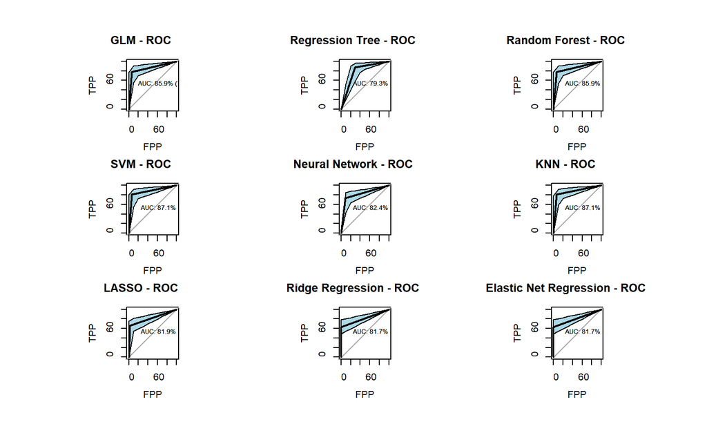

```r
# create object to combine plots
par(mfrow=c(3,3))
par(pty = "s")
par(oma = c(3, 3, 3, 3), mar=c(1, 1, 1, 1), mgp=c(2, 0.8, 0), las=0)

# plot AUC-ROC for the Logistic Regression model
glm_obj <- roc(test_data$Diagnosis_Heart_Disease, as.numeric(glm_pred), ci=TRUE, ci.alpha=0.9,
               plot=TRUE, legacy.axes = TRUE, percent=TRUE,
               #xlab="False Positive Percentage", ylab="True Positive Percentage",
               xlab="FPP", ylab="TPP",
               print.auc.x=80, print.auc.y=60,
               print.auc=TRUE, show.thres=TRUE)
sens.ci_glm <- ci.se(glm_obj)
plot(sens.ci_glm, type = "shape", col="lightblue",
     title(main="GLM - ROC", line=.25))
     #title(main="Generalized Linear Model - ROC", line=3))


# plot AUC-ROC for Regression Tree model
rt_obj <- roc(test_data$Diagnosis_Heart_Disease, as.numeric(rt_pred), ci=TRUE, ci.alpha=0.9,
              plot=TRUE, legacy.axes = TRUE, percent=TRUE,
              #xlab="False Positive Percentage", ylab="True Positive Percentage",
              xlab="FPP", ylab="TPP",
              print.auc.x=75, print.auc.y=60,
              print.auc=TRUE, show.thres=TRUE)
sens.ci_rt <- ci.se(rt_obj)
plot(sens.ci_rt, type = "shape", col="lightblue",
     title(main="Regression Tree - ROC", line=.25))
# plot AUC-ROC for the Random Forest model
rf_obj <- roc(test_data$Diagnosis_Heart_Disease, as.numeric(rf_pred), ci=TRUE, ci.alpha=0.9,
              plot=TRUE, legacy.axes = TRUE, percent=TRUE,
              #xlab="False Positive Percentage", ylab="True Positive Percentage",
              xlab="FPP", ylab="TPP",
              print.auc.x=75, print.auc.y=60,
              print.auc=TRUE, show.thres=TRUE)
sens.ci_rf <- ci.se(rf_obj)
plot(sens.ci_rf, type = "shape", col="lightblue",
     title(main="Random Forest - ROC", line=.25))
# plot AUC-ROC for the SVM model
svm_obj <- roc(test_data$Diagnosis_Heart_Disease, as.numeric(svm_pred), ci=TRUE, ci.alpha=0.9,
               plot=TRUE, legacy.axes = TRUE, percent=TRUE,
               #xlab="False Positive Percentage", ylab="True Positive Percentage",
               xlab="FPP", ylab="TPP",
               print.auc.x=75, print.auc.y=60,
               print.auc=TRUE, show.thres=TRUE)
sens.ci_svm <- ci.se(svm_obj)
plot(sens.ci_svm, type = "shape", col="lightblue",
     title(main="SVM - ROC", line=.25))
# plot AUC-ROC for the Neural Networks model
nn_obj <- roc(test_data$Diagnosis_Heart_Disease, as.numeric(nn_pred$V1),ci=TRUE, ci.alpha=0.9,
              plot=TRUE, legacy.axes = TRUE, percent=TRUE,
              #xlab="False Positive Percentage", ylab="True Positive Percentage",
              xlab="FPP", ylab="TPP",
              print.auc.x=75, print.auc.y=60,
              print.auc=TRUE, show.thres=TRUE)
sens.ci_nn <- ci.se(nn_obj)
plot(sens.ci_nn, type = "shape", col="lightblue",
     title(main="Neural Network - ROC", line=.25))
# plot AUC-ROC for k-Nearest Neighbors model
knn_obj <- roc(test_data$Diagnosis_Heart_Disease, as.numeric(knn_pred), ci=TRUE, ci.alpha=0.9,
               plot=TRUE, legacy.axes = TRUE, percent=TRUE,
               #xlab="False Positive Percentage", ylab="True Positive Percentage",
               xlab="FPP", ylab="TPP",
               print.auc.x=75, print.auc.y=60,
               print.auc=TRUE, show.thres=TRUE)
sens.ci_knn <- ci.se(knn_obj)
plot(sens.ci_knn, type = "shape", col="lightblue",
     title(main="KNN - ROC", line=.25))
# plot AUC-ROC for LASSO model
lasso_obj <- roc(lasso_test$Diagnosis_Heart_Disease, as.numeric(lasso_pred$s0), ci=TRUE, ci.alpha=0.9,
               plot=TRUE, legacy.axes = TRUE, percent=TRUE,
               #xlab="False Positive Percentage", ylab="True Positive Percentage",
               xlab="FPP", ylab="TPP",
               print.auc.x=75, print.auc.y=60,
               print.auc=TRUE, show.thres=TRUE)
sens.ci_lasso <- ci.se(lasso_obj)
plot(sens.ci_lasso, type = "shape", col="lightblue",
     title(main="LASSO - ROC", line=.25))
# plot AUC-ROC for Ridge Regression model
ridge_obj <- roc(ridge_test$Diagnosis_Heart_Disease, as.numeric(ridge_pred$s0), ci=TRUE, ci.alpha=0.9,
               plot=TRUE, legacy.axes = TRUE, percent=TRUE,
               #xlab="False Positive Percentage", ylab="True Positive Percentage",
               xlab="FPP", ylab="TPP",
               print.auc.x=75, print.auc.y=60,
               print.auc=TRUE, show.thres=TRUE)
sens.ci_ridge <- ci.se(ridge_obj)
plot(sens.ci_ridge, type = "shape", col="lightblue",
     title(main="Ridge Regression - ROC", line=.25))
# plot AUC-ROC for Elastic Net Regression model
elastic_obj <- roc(elastic_test$Diagnosis_Heart_Disease, as.numeric(elastic_pred$s0), ci=TRUE, ci.alpha=0.9,
               plot=TRUE, legacy.axes = TRUE, percent=TRUE,
               #xlab="False Positive Percentage", ylab="True Positive Percentage",
               xlab="FPP", ylab="TPP",
               print.auc.x=75, print.auc.y=60,
               print.auc=TRUE, show.thres=TRUE)
sens.ci_elastic <- ci.se(elastic_obj)
plot(sens.ci_elastic, type = "shape", col="lightblue",
     title(main="Elastic Net Regression - ROC", line=.25))
```

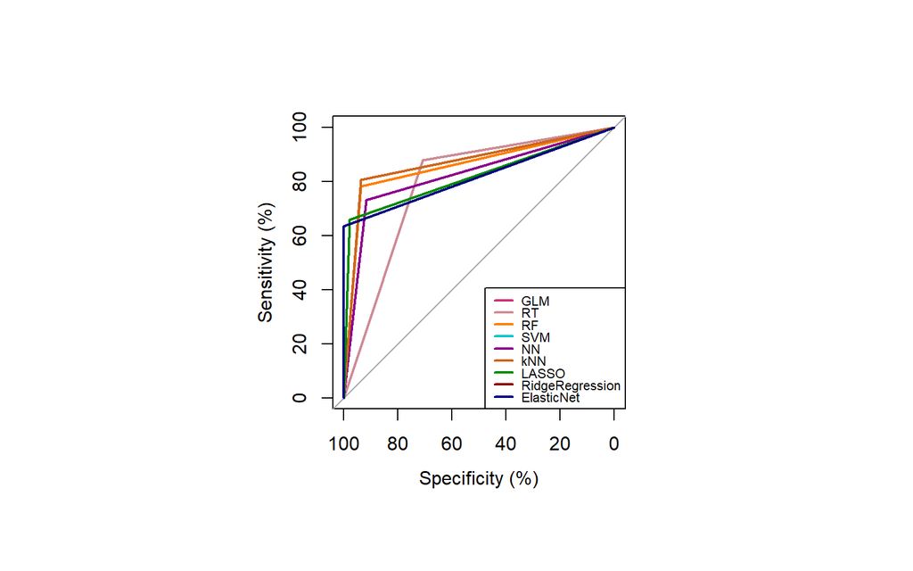

```r
par(mfrow=c(1,1))
# Make a composite plot of ROC-AUCs
plot(glm_obj, col="violetred3")
plot(rt_obj, col="lightpink3", add=TRUE)
plot(rf_obj, col="darkorange1", add=TRUE)
plot(svm_obj, col="turquoise3", add=TRUE)
plot(nn_obj, col="darkmagenta", add=TRUE)
plot(knn_obj, col="chocolate3", add=TRUE)
plot(lasso_obj, col="green4", add=TRUE)
plot(ridge_obj, col="red4", add=TRUE)
plot(elastic_obj, col="navyblue", add=TRUE)
legend("bottomright", c("GLM","RT","RF","SVM","NN","kNN", "LASSO", "RidgeRegression", "ElasticNet"), lty=1, lwd=2, cex=0.7,
col=c("violetred3","lightpink3","darkorange1","turquoise3","darkmagenta","chocolate3", "green4", "red4", "navyblue"))
```

```r
#text(locator(), labels = c("GLM","RT","RF","SVM","NN","kNN", "LASSO", "RidgeRegression", "ElasticNet"))

# Summary of model performance metrics
model_accs %>% knitr::kable()
```

| Method | Accuracy | Sensitivity/Recall | F1 score | AUC |
| --- | --- | --- | --- | --- |
| Generalized Linear Model | 0.8651685 | 0.8333333 | 0.8719346 | 0.858 |
| Bayesian GLM | 0.8876404 | 0.8518519 | 0.8950472 | 0.881 |
| Regression Tree Model | 0.7865169 | 0.8717949 | 0.7886598 | 0.793 |
| Random Forest Model | 0.8651685 | 0.8333333 | 0.8719346 | 0.858 |
| Support-Vector Machine | 0.8764045 | 0.8490566 | 0.8815672 | 0.871 |
| Neural Network | 0.8314607 | 0.8000000 | 0.8391608 | 0.824 |
| k-Nearest Neighbors | 0.8764045 | 0.8490566 | 0.8815672 | 0.871 |
| LASSO | 0.8314607 | 0.7704918 | 0.8565643 | 0.818 |
| Ridge | 0.8314607 | 0.7619048 | 0.8648649 | 0.817 |
| Elastic Net | 0.8314607 | 0.7619048 | 0.8648649 | 0.817 |

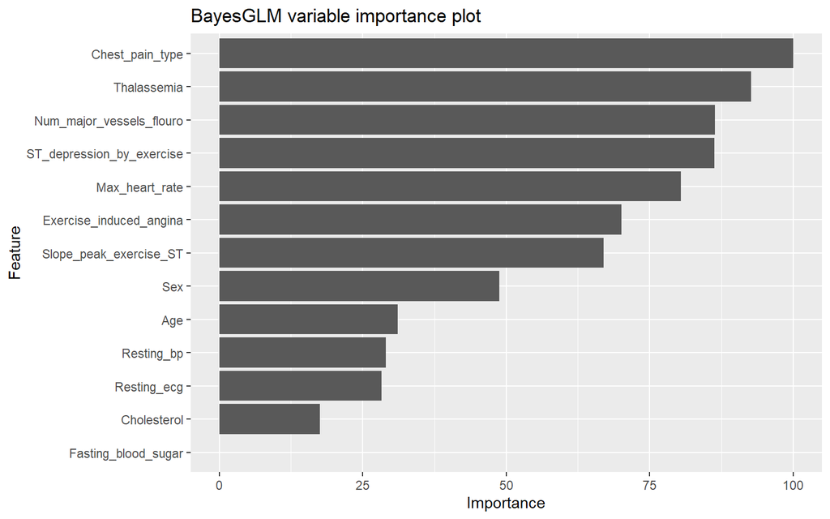

```r
# Important variables - Bayesian GLM
ggplot2::ggplot(varImp(bayesglm_fit)) +
                ggtitle("BayesGLM variable importance plot")
```

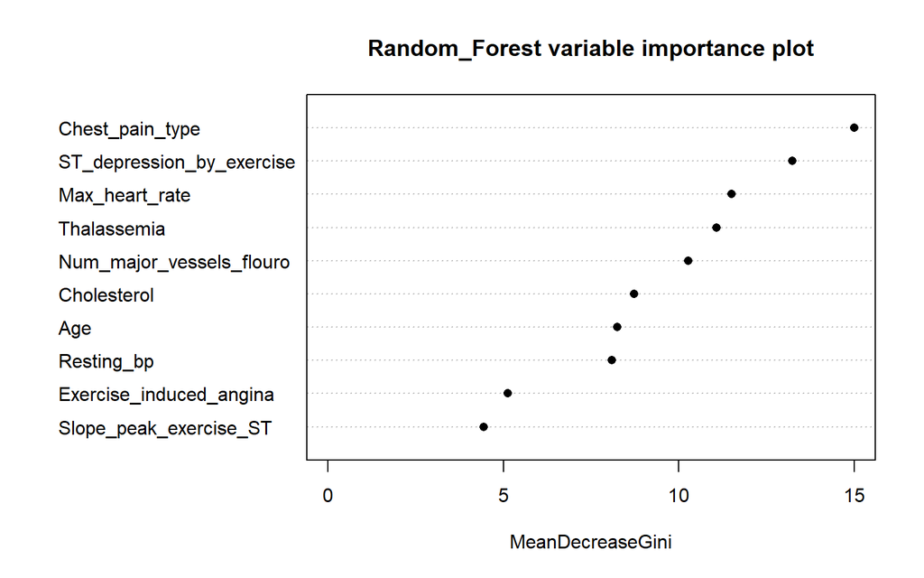

```r
# Important variables - RF
varImpPlot(rf_fit, type=2, main="Random_Forest variable importance plot",
           pch = 16, col.lab="black",
           n.var=min(10, nrow(rf_fit$importance)))
```

```r
#knnImp <- varImp(knn_fit)
#dotPlot(knnImp, main = "kNN variable importance plot" )
#dotPlot(varImp(bayesglm_fit), main = "BayesGLM variable importance plot" )
```